# Meta-analysis physiological costs of hibernation: Report 4 - Arousal OS

Pablo Capilla-Lasheras

2025-04-07

This [R Markdown](http://rmarkdown.rstudio.com) Notebook contains the initial meta-analysis for the project ‘physiological ’costs’ of hibernation.

## Dataset and calculation of effect sizes

The dataset for this meta-analysis has been collected after a literature search by Pablo Burraco, Marko Prokic and Tamara Petrovic. It contains data on physiological effects of hibernation in different systems. Here a quick snapshot of the first lines of the dataset:

|  | Reference | Year | Study_ID | Species | Family | Genus | Common.name | Type_of_animal | Thermoregulation | Class | Class_2 | Ver_Invert | Developmental_stage | Location | Experiment_venue | Biological.process | Tissue | Experimental_manipulation | Experimental.value | Biomarker_category | Biomarker_cat_2 | Biomarker_cat_3 | Specific_biomarker | Unit | Euthermia_N | Euthermia_M | Euthermia_SD | Euthermia_SE | Hib_N | … |
| --- | --- | --- | --- | --- | --- | --- | --- | --- | --- | --- | --- | --- | --- | --- | --- | --- | --- | --- | --- | --- | --- | --- | --- | --- | --- | --- | --- | --- | --- | --- |
| 1 | Afifi and Alkaladi, 2014 | 2014 | study 32 | Uromastyx ornata | Agamidae | Uromastyx | ornate mastigure | Lizard | Ectothermic | Reptilia | Reptilia | Vertebrate | adults | Saudi Arabia | Field | hibernation | BAT | NA | male | Non-enzymatic | Antioxidant | Non-enzymatic | Vit E | mg/L homogenate | 10 | 1.220000e+03 | NA | 1.300000e+02 | 10 | … |
| 2 | Afifi and Alkaladi, 2014 | 2014 | study 32 | Uromastyx ornata | Agamidae | Uromastyx | ornate mastigure | Lizard | Ectothermic | Reptilia | Reptilia | Vertebrate | adults | Saudi Arabia | Field | hibernation | blood serum | NA | male | Non-enzymatic | Antioxidant | Non-enzymatic | Vit E | mg/L homogenate | 10 | 4.500000e+02 | NA | 3.600000e+01 | 10 | … |
| 3 | Afifi and Alkaladi, 2014 | 2014 | study 32 | Uromastyx ornata | Agamidae | Uromastyx | ornate mastigure | Lizard | Ectothermic | Reptilia | Reptilia | Vertebrate | adults | Saudi Arabia | Field | hibernation | brain | NA | male | Non-enzymatic | Antioxidant | Non-enzymatic | Vit E | mg/L homogenate | 10 | 1.600000e+03 | NA | 2.540000e+02 | 10 | … |
| 4 | Afifi and Alkaladi, 2014 | 2014 | study 32 | Uromastyx ornata | Agamidae | Uromastyx | ornate mastigure | Lizard | Ectothermic | Reptilia | Reptilia | Vertebrate | adults | Saudi Arabia | Field | hibernation | liver | NA | male | Non-enzymatic | Antioxidant | Non-enzymatic | Vit E | mg/L homogenate | 10 | 1.676000e+03 | NA | 1.720000e+02 | 10 | … |
| 5 | Afifi and Alkaladi, 2014 | 2014 | study 32 | Uromastyx ornata | Agamidae | Uromastyx | ornate mastigure | Lizard | Ectothermic | Reptilia | Reptilia | Vertebrate | adults | Saudi Arabia | Field | hibernation | BAT | NA | male | Enzymatic | Antioxidant | Enzymatic | GPx | μM /min/g tissue | 10 | 4.460000e+01 | NA | 2.300000e+00 | 10 | … |
| 6 | Afifi and Alkaladi, 2014 | 2014 | study 32 | Uromastyx ornata | Agamidae | Uromastyx | ornate mastigure | Lizard | Ectothermic | Reptilia | Reptilia | Vertebrate | adults | Saudi Arabia | Field | hibernation | brain | NA | male | Enzymatic | Antioxidant | Enzymatic | GR | unit/g tissue | 10 | 4.440000e+01 | NA | 4.400000e+00 | 10 | … |
| 7 | Afifi and Alkaladi, 2014 | 2014 | study 32 | Uromastyx ornata | Agamidae | Uromastyx | ornate mastigure | Lizard | Ectothermic | Reptilia | Reptilia | Vertebrate | adults | Saudi Arabia | Field | hibernation | liver | NA | male | Enzymatic | Antioxidant | Enzymatic | GR | unit/g tissue | 10 | 5.700000e+01 | NA | 5.000000e+00 | 10 | … |
| 8 | Afifi and Alkaladi, 2014 | 2014 | study 32 | Uromastyx ornata | Agamidae | Uromastyx | ornate mastigure | Lizard | Ectothermic | Reptilia | Reptilia | Vertebrate | adults | Saudi Arabia | Field | hibernation | blood serum | NA | male | Enzymatic | Antioxidant | Enzymatic | GPx | μM /min/g tissue | 10 | 3.540000e+01 | NA | 3.900000e+00 | 10 | … |
| 9 | Afifi and Alkaladi, 2014 | 2014 | study 32 | Uromastyx ornata | Agamidae | Uromastyx | ornate mastigure | Lizard | Ectothermic | Reptilia | Reptilia | Vertebrate | adults | Saudi Arabia | Field | hibernation | liver | NA | male | Enzymatic | Antioxidant | Enzymatic | GPx | μM /min/g tissue | 10 | 4.200000e+01 | NA | 4.000000e+00 | 10 | … |
| 10 | Afifi and Alkaladi, 2014 | 2014 | study 32 | Uromastyx ornata | Agamidae | Uromastyx | ornate mastigure | Lizard | Ectothermic | Reptilia | Reptilia | Vertebrate | adults | Saudi Arabia | Field | hibernation | brain | NA | male | Enzymatic | Antioxidant | Enzymatic | GPx | μM /min/g tissue | 10 | 4.140000e+01 | NA | 2.300000e+00 | 10 | … |

[output cut: 1012 more lines]

As a summary of the *initial dataset*:

- Number of studies: 61
- Number of species: 29

For this initial meta-analysis, I am going to include all oxidative stress (OS) markers and calculate the standarised mean difference (g) as the effect size of analysis comparing **arousal** *versus* **euthermia**. Positive SMD values indicate higher OS values in *arousal* while negative SMD indicate lower OS values in *arousal*. This is a summary of the effect size calculation based on the dataset above:

Summary of SMD effect size and number of observations included in the meta-analysis:

```
##    Min. 1st Qu.  Median    Mean 3rd Qu.    Max.
## -4.0681 -0.4049  0.5374  0.6009  1.3812 10.5059
```

- Number of observation with non-missing SMD: 590
- Number of studies in the dataset for analysis: 31
- Number of species in the dataset for analysis: 17

## Initial meta-analysis:

This initial model contains only the intercept and five random effects to account for variation between between classes, families, species, between studies and within studies beyond sampling variance.

```r
model_SMD <- rma.mv(yi = SMDH_arousal,
                    V = SMDH.sv_arousal,
                    mods = ~ 1,
                    random = list(~1|Study_ID,
                                  ~1|Class,
                                  ~1|Family,
                                  ~1|Species,
                                  ~1|obsID),
                    data=df_SMD,
                    method="REML")
```

```
##
## Multivariate Meta-Analysis Model (k = 590; method: REML)
##
##     logLik    Deviance         AIC         BIC        AICc
## -1056.0970   2112.1941   2124.1941   2150.4647   2124.3384
##
## Variance Components:
##
##             estim    sqrt  nlvls  fixed    factor
## sigma^2.1  0.2947  0.5429     31     no  Study_ID
## sigma^2.2  1.6325  1.2777      6     no     Class
## sigma^2.3  0.0000  0.0000     11     no    Family
## sigma^2.4  0.0000  0.0013     17     no   Species
## sigma^2.5  1.0701  1.0345    590     no     obsID
##
## Test for Heterogeneity:
## Q(df = 589) = 2230.6197, p-val < .0001
##
## Model Results:
##
## estimate      se    zval    pval    ci.lb   ci.ub
##   0.9024  0.5643  1.5992  0.1098  -0.2036  2.0083
##
## ---
## Signif. codes:  0 '***' 0.001 '**' 0.01 '*' 0.05 '.' 0.1 ' ' 1
```

Proportion of variation left after accounting for sampling variance and proportion accounted by each random effect:

| Variable | i2_value_percentage |
| --- | --- |
| I2_Total | 87.826 |
| I2_Study_ID | 8.636 |
| I2_Class | 47.833 |
| I2_Family | 0.000 |
| I2_Species | 0.000 |
| I2_obsID | 31.356 |

### Plot of results of intercept-only model:

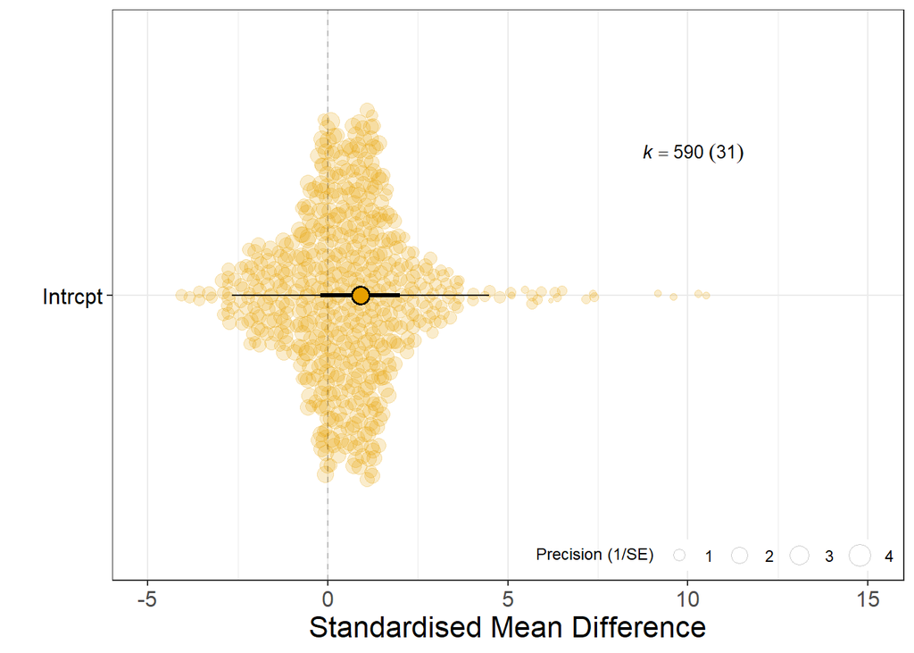

### Publication bias: small-study effects

```
##
## Multivariate Meta-Analysis Model (k = 590; method: REML)
##
##     logLik    Deviance         AIC         BIC        AICc
## -1054.1700   2108.3400   2122.3400   2152.9771   2122.5331
##
## Variance Components:
##
##             estim    sqrt  nlvls  fixed    factor
## sigma^2.1  0.3128  0.5593     31     no  Study_ID
## sigma^2.2  1.6718  1.2930      6     no     Class
## sigma^2.3  0.0000  0.0000     11     no    Family
## sigma^2.4  0.0000  0.0006     17     no   Species
## sigma^2.5  1.0709  1.0348    590     no     obsID
##
## Test for Residual Heterogeneity:
## QE(df = 588) = 2230.5540, p-val < .0001
##
## Test of Moderators (coefficient 2):
## QM(df = 1) = 0.0291, p-val = 0.8646
##
## Model Results:
##
##                   estimate      se     zval    pval    ci.lb   ci.ub
## intrcpt             1.0344  0.9597   1.0779  0.2811  -0.8465  2.9154
## sqrt(inv_eff_ss)   -0.2263  1.3264  -0.1706  0.8646  -2.8261  2.3735
##
## ---
## Signif. codes:  0 '***' 0.001 '**' 0.01 '*' 0.05 '.' 0.1 ' ' 1
```

```
##    R2_marginal R2_conditional
##   0.0001199524   0.6495544632
```

### Publication bias: time-lag effects

```
##
## Multivariate Meta-Analysis Model (k = 590; method: REML)
##
##     logLik    Deviance         AIC         BIC        AICc
## -1053.9348   2107.8696   2121.8696   2152.5067   2122.0627
##
## Variance Components:
##
##             estim    sqrt  nlvls  fixed    factor
## sigma^2.1  0.3132  0.5596     31     no  Study_ID
## sigma^2.2  1.6130  1.2700      6     no     Class
## sigma^2.3  0.0000  0.0000     11     no    Family
## sigma^2.4  0.0000  0.0018     17     no   Species
## sigma^2.5  1.0711  1.0349    590     no     obsID
##
## Test for Residual Heterogeneity:
## QE(df = 588) = 2197.6922, p-val < .0001
##
## Test of Moderators (coefficient 2):
## QM(df = 1) = 0.0382, p-val = 0.8451
##
## Model Results:
##
##              estimate      se    zval    pval    ci.lb   ci.ub
## intrcpt        0.8998  0.5629  1.5985  0.1099  -0.2035  2.0030
## scale(Year)    0.0276  0.1413  0.1954  0.8451  -0.2493  0.3046
##
## ---
## Signif. codes:  0 '***' 0.001 '**' 0.01 '*' 0.05 '.' 0.1 ' ' 1
```

```
##    R2_marginal R2_conditional
##   0.0002541895   0.6427262090
```

## Meta-analysis with all organisms but including different OS markers:

Number of observations for each type:

```
##
##      Antioxidant Oxidative_damage       Regulatory              ROS
##              443               91               27               29
```

```
##
## Multivariate Meta-Analysis Model (k = 590; method: REML)
##
##     logLik    Deviance         AIC         BIC        AICc
## -1023.7773   2047.5546   2065.5546   2104.9145   2065.8671
##
## Variance Components:
##
##             estim    sqrt  nlvls  fixed    factor
## sigma^2.1  0.2033  0.4509     31     no  Study_ID
## sigma^2.2  1.5527  1.2461      6     no     Class
## sigma^2.3  0.0000  0.0000     11     no    Family
## sigma^2.4  0.0000  0.0005     17     no   Species
## sigma^2.5  0.8880  0.9423    590     no     obsID
##
## Test for Residual Heterogeneity:
## QE(df = 586) = 2010.4292, p-val < .0001
##
## Test of Moderators (coefficients 1:4):
## QM(df = 4) = 64.6158, p-val < .0001
##
## Model Results:
##
##                                  estimate      se     zval    pval    ci.lb
## Biomarker_cat_2Antioxidant         1.0744  0.5440   1.9749  0.0483   0.0081
## Biomarker_cat_2Oxidative_damage    0.2047  0.5554   0.3686  0.7124  -0.8839
## Biomarker_cat_2Regulatory          1.2558  0.6091   2.0618  0.0392   0.0620
## Biomarker_cat_2ROS                -0.1359  0.5859  -0.2320  0.8165  -1.2844
##                                   ci.ub
## Biomarker_cat_2Antioxidant       2.1407  *
## Biomarker_cat_2Oxidative_damage  1.2933
## Biomarker_cat_2Regulatory        2.4495  *
## Biomarker_cat_2ROS               1.0125
##
## ---
## Signif. codes:  0 '***' 0.001 '**' 0.01 '*' 0.05 '.' 0.1 ' ' 1
```

```
##
## Multivariate Meta-Analysis Model (k = 590; method: REML)
##
##     logLik    Deviance         AIC         BIC        AICc
## -1023.7773   2047.5546   2065.5546   2104.9145   2065.8671
##
## Variance Components:
##
##             estim    sqrt  nlvls  fixed    factor
## sigma^2.1  0.2033  0.4509     31     no  Study_ID
## sigma^2.2  1.5527  1.2461      6     no     Class
## sigma^2.3  0.0000  0.0000     11     no    Family
## sigma^2.4  0.0000  0.0005     17     no   Species
## sigma^2.5  0.8880  0.9423    590     no     obsID
##
## Test for Residual Heterogeneity:
## QE(df = 586) = 2010.4292, p-val < .0001
##
## Test of Moderators (coefficients 1:4):
## QM(df = 4) = 64.6158, p-val < .0001
##
## Model Results:
##
##                                  estimate      se     zval    pval    ci.lb
## Biomarker_cat_2Antioxidant         1.0744  0.5440   1.9749  0.0483   0.0081
## Biomarker_cat_2Oxidative_damage    0.2047  0.5554   0.3686  0.7124  -0.8839
## Biomarker_cat_2Regulatory          1.2558  0.6091   2.0618  0.0392   0.0620
## Biomarker_cat_2ROS                -0.1359  0.5859  -0.2320  0.8165  -1.2844
##                                   ci.ub
## Biomarker_cat_2Antioxidant       2.1407  *
## Biomarker_cat_2Oxidative_damage  1.2933
## Biomarker_cat_2Regulatory        2.4495  *
## Biomarker_cat_2ROS               1.0125
##
## ---
## Signif. codes:  0 '***' 0.001 '**' 0.01 '*' 0.05 '.' 0.1 ' ' 1
```

### Plot of results of biomarker meta-regression:

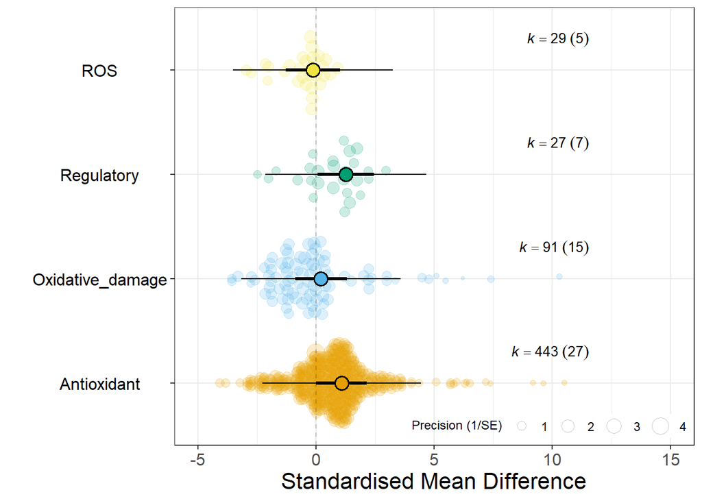

## Meta-analysis including thermoregulation type as a moderator:

Number of observations for each type:

```
##
## Ectothermic Endothermic
##         190         400
```

```
##
## Multivariate Meta-Analysis Model (k = 590; method: REML)
##
##     logLik    Deviance         AIC         BIC        AICc
## -1052.2051   2104.4101   2118.4101   2149.0472   2118.6032
##
## Variance Components:
##
##             estim    sqrt  nlvls  fixed    factor
## sigma^2.1  0.2866  0.5353     31     no  Study_ID
## sigma^2.2  2.0459  1.4303      6     no     Class
## sigma^2.3  0.0003  0.0176     11     no    Family
## sigma^2.4  0.0058  0.0763     17     no   Species
## sigma^2.5  1.0709  1.0348    590     no     obsID
##
## Test for Residual Heterogeneity:
## QE(df = 588) = 2216.0065, p-val < .0001
##
## Test of Moderators (coefficients 1:2):
## QM(df = 2) = 2.3927, p-val = 0.3023
##
## Model Results:
##
##                              estimate      se    zval    pval    ci.lb   ci.ub
## ThermoregulationEctothermic    1.0605  0.6910  1.5348  0.1248  -0.2938  2.4149
## ThermoregulationEndothermic    0.2776  1.4395  0.1928  0.8471  -2.5437  3.0989
##
## ThermoregulationEctothermic
## ThermoregulationEndothermic
##
## ---
## Signif. codes:  0 '***' 0.001 '**' 0.01 '*' 0.05 '.' 0.1 ' ' 1
```

```
##
## Multivariate Meta-Analysis Model (k = 590; method: REML)
##
##     logLik    Deviance         AIC         BIC        AICc
## -1052.2051   2104.4101   2118.4101   2149.0472   2118.6032
##
## Variance Components:
##
##             estim    sqrt  nlvls  fixed    factor
## sigma^2.1  0.2866  0.5353     31     no  Study_ID
## sigma^2.2  2.0459  1.4303      6     no     Class
## sigma^2.3  0.0003  0.0176     11     no    Family
## sigma^2.4  0.0058  0.0763     17     no   Species
## sigma^2.5  1.0709  1.0348    590     no     obsID
##
## Test for Residual Heterogeneity:
## QE(df = 588) = 2216.0065, p-val < .0001
##
## Test of Moderators (coefficients 1:2):
## QM(df = 2) = 2.3927, p-val = 0.3023
##
## Model Results:
##
##                              estimate      se    zval    pval    ci.lb   ci.ub
## ThermoregulationEctothermic    1.0605  0.6910  1.5348  0.1248  -0.2938  2.4149
## ThermoregulationEndothermic    0.2776  1.4395  0.1928  0.8471  -2.5437  3.0989
##
## ThermoregulationEctothermic
## ThermoregulationEndothermic
##
## ---
## Signif. codes:  0 '***' 0.001 '**' 0.01 '*' 0.05 '.' 0.1 ' ' 1
```

### Plot of results of thermoregulation meta-regression:

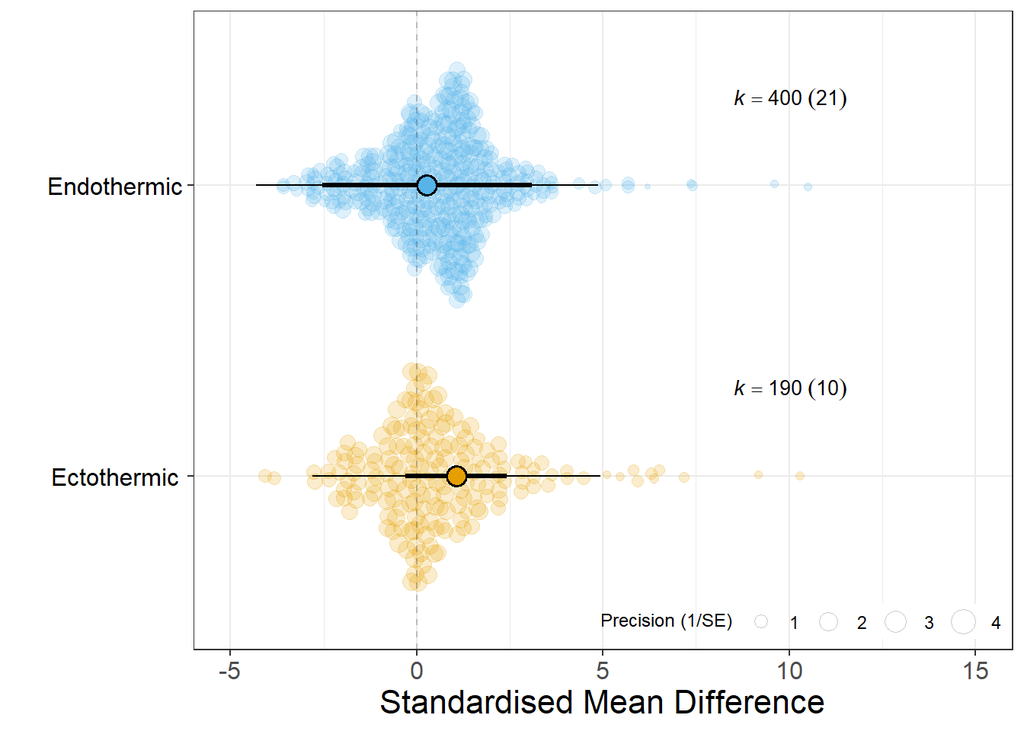

## Endotherms vs. ectotherms:

Now, we investigate if the response to arousal varies across biomarkers of oxidative stress for endotherms and ectotherms. We include four markers:

```
##
##      Antioxidant Oxidative_damage       Regulatory              ROS
##              443               91               27               29
```

### Meta-model for endotherms:

- Number of observation with non-missing SMD: 400
- Number of studies in the dataset for analysis: 21
- Number of species in the dataset for analysis: 10

```
##
## Multivariate Meta-Analysis Model (k = 400; method: REML)
##
##    logLik   Deviance        AIC        BIC       AICc
## -681.3676  1362.7351  1378.7351  1410.5865  1379.1072
##
## Variance Components:
##
##             estim    sqrt  nlvls  fixed    factor
## sigma^2.1  0.0000  0.0000     21     no  Study_ID
## sigma^2.2  0.0000  0.0003      4     no    Family
## sigma^2.3  0.1388  0.3725     10     no   Species
## sigma^2.4  0.8369  0.9148    400     no     obsID
##
## Test for Residual Heterogeneity:
## QE(df = 396) = 1203.0246, p-val < .0001
##
## Test of Moderators (coefficients 1:4):
## QM(df = 4) = 82.6564, p-val < .0001
##
## Model Results:
##
##                                  estimate      se     zval    pval    ci.lb
## Biomarker_cat_2Antioxidant         0.3935  0.1611   2.4427  0.0146   0.0778
## Biomarker_cat_2Oxidative_damage   -1.0178  0.2285  -4.4534  <.0001  -1.4657
## Biomarker_cat_2Regulatory          0.5296  0.2816   1.8807  0.0600  -0.0223
## Biomarker_cat_2ROS                -0.8926  0.2541  -3.5128  0.0004  -1.3906
##                                    ci.ub
## Biomarker_cat_2Antioxidant        0.7092    *
## Biomarker_cat_2Oxidative_damage  -0.5698  ***
## Biomarker_cat_2Regulatory         1.0814    .
## Biomarker_cat_2ROS               -0.3946  ***
##
## ---
## Signif. codes:  0 '***' 0.001 '**' 0.01 '*' 0.05 '.' 0.1 ' ' 1
```

```
##
## Multivariate Meta-Analysis Model (k = 400; method: REML)
##
##    logLik   Deviance        AIC        BIC       AICc
## -681.3676  1362.7351  1378.7351  1410.5865  1379.1072
##
## Variance Components:
##
##             estim    sqrt  nlvls  fixed    factor
## sigma^2.1  0.0000  0.0000     21     no  Study_ID
## sigma^2.2  0.0000  0.0003      4     no    Family
## sigma^2.3  0.1388  0.3725     10     no   Species
## sigma^2.4  0.8369  0.9148    400     no     obsID
##
## Test for Residual Heterogeneity:
## QE(df = 396) = 1203.0246, p-val < .0001
##
## Test of Moderators (coefficients 1:4):
## QM(df = 4) = 82.6564, p-val < .0001
##
## Model Results:
##
##                                  estimate      se     zval    pval    ci.lb
## Biomarker_cat_2Antioxidant         0.3935  0.1611   2.4427  0.0146   0.0778
## Biomarker_cat_2Oxidative_damage   -1.0178  0.2285  -4.4534  <.0001  -1.4657
## Biomarker_cat_2Regulatory          0.5296  0.2816   1.8807  0.0600  -0.0223
## Biomarker_cat_2ROS                -0.8926  0.2541  -3.5128  0.0004  -1.3906
##                                    ci.ub
## Biomarker_cat_2Antioxidant        0.7092    *
## Biomarker_cat_2Oxidative_damage  -0.5698  ***
## Biomarker_cat_2Regulatory         1.0814    .
## Biomarker_cat_2ROS               -0.3946  ***
##
## ---
## Signif. codes:  0 '***' 0.001 '**' 0.01 '*' 0.05 '.' 0.1 ' ' 1
```

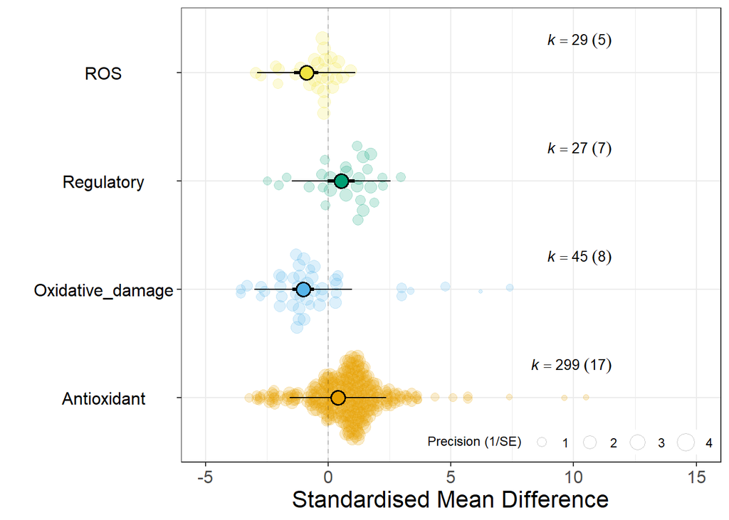

### Meta-model for ectotherms:

- Number of observation with non-missing SMD: 190
- Number of studies in the dataset for analysis: 10
- Number of species in the dataset for analysis: 7

```
##
## Multivariate Meta-Analysis Model (k = 190; method: REML)
##
##    logLik   Deviance        AIC        BIC       AICc
## -326.8844   653.7687   667.7687   690.4238   668.3910
##
## Variance Components:
##
##             estim    sqrt  nlvls  fixed    factor
## sigma^2.1  0.3228  0.5682     10     no  Study_ID
## sigma^2.2  1.9308  1.3895      5     no     Class
## sigma^2.3  0.0000  0.0001      7     no    Family
## sigma^2.4  0.0000  0.0001      7     no   Species
## sigma^2.5  0.8271  0.9095    190     no     obsID
##
## Test for Residual Heterogeneity:
## QE(df = 188) = 740.9758, p-val < .0001
##
## Test of Moderators (coefficients 1:2):
## QM(df = 2) = 3.3132, p-val = 0.1908
##
## Model Results:
##
##                                  estimate      se    zval    pval    ci.lb
## Biomarker_cat_2Antioxidant         1.0852  0.6766  1.6038  0.1087  -0.2410
## Biomarker_cat_2Oxidative_damage    0.8850  0.6948  1.2738  0.2027  -0.4767
##                                   ci.ub
## Biomarker_cat_2Antioxidant       2.4114
## Biomarker_cat_2Oxidative_damage  2.2468
##
## ---
## Signif. codes:  0 '***' 0.001 '**' 0.01 '*' 0.05 '.' 0.1 ' ' 1
```

```
##
## Multivariate Meta-Analysis Model (k = 190; method: REML)
##
##    logLik   Deviance        AIC        BIC       AICc
## -326.8844   653.7687   667.7687   690.4238   668.3910
##
## Variance Components:
##
##             estim    sqrt  nlvls  fixed    factor
## sigma^2.1  0.3228  0.5682     10     no  Study_ID
## sigma^2.2  1.9308  1.3895      5     no     Class
## sigma^2.3  0.0000  0.0001      7     no    Family
## sigma^2.4  0.0000  0.0001      7     no   Species
## sigma^2.5  0.8271  0.9095    190     no     obsID
##
## Test for Residual Heterogeneity:
## QE(df = 188) = 740.9758, p-val < .0001
##
## Test of Moderators (coefficients 1:2):
## QM(df = 2) = 3.3132, p-val = 0.1908
##
## Model Results:
##
##                                  estimate      se    zval    pval    ci.lb
## Biomarker_cat_2Antioxidant         1.0852  0.6766  1.6038  0.1087  -0.2410
## Biomarker_cat_2Oxidative_damage    0.8850  0.6948  1.2738  0.2027  -0.4767
##                                   ci.ub
## Biomarker_cat_2Antioxidant       2.4114
## Biomarker_cat_2Oxidative_damage  2.2468
##
## ---
## Signif. codes:  0 '***' 0.001 '**' 0.01 '*' 0.05 '.' 0.1 ' ' 1
```

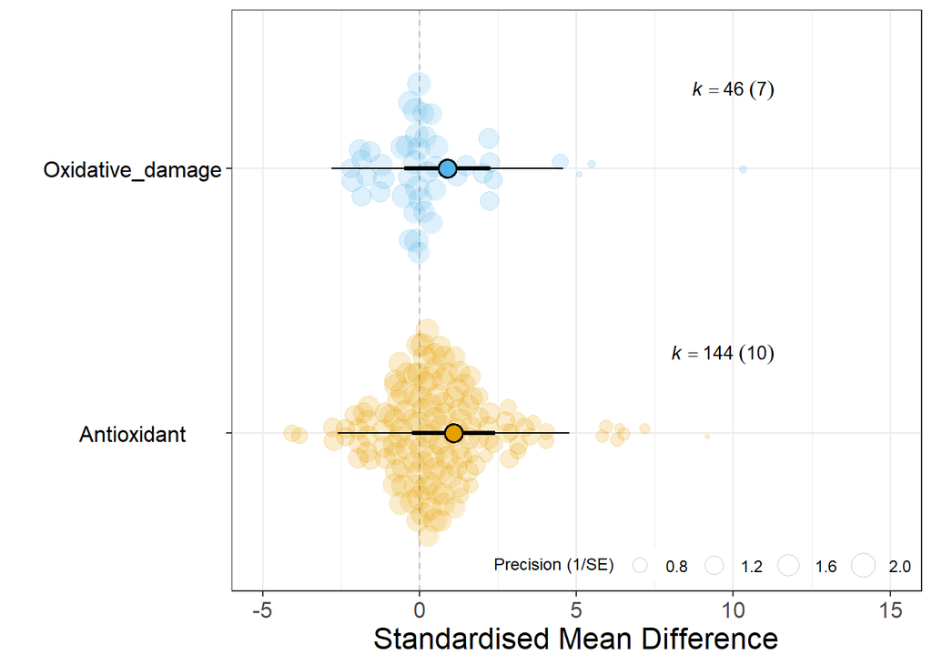